# 時系列分析 第1回

時系列分析の基礎概念1

Kenichiro Tamaki

2022年4月11日

# 1. 時系列分析の基礎概念

## 1.1 時系列分析の基礎

### 1.1.1 時系列分析の目的

**時系列データ**

- 時系列データ (time series data)
  - 時間の推移とともに観測されるデータ
  - 例1: 2001年から2020年までの日本の年次名目GDP (観測数20)
  - 例2: 2001年1月から2020年12月までの月次日経平均株価 (観測数240)
- 横断面データ (cross section data)
  - ある1時点において観測されるデータ
  - 例1: 20カ国の2020年の実質GDP (観測数20)
  - 例2: 1,000人の2020年の給与所得 (観測数1,000)
- パネルデータ (panel data)
  - 時系列と横断面をまとめたデータ
  - 例1: 20カ国の2001年から2020年までの年次名目GDP
  - 例2: 1,000人の2001年から2020年までの給与所得, 年齢, 最終学歴

**時系列データのプロット**

- 横軸に時間, 縦軸にデータの値をプロットする
  - 図1.1 (p.2) 代表的な経済・ファイナンス時系列データ
  - 図1.2 (p.3) 代表的な経済・ファイナンス時系列データの変化率

**時系列データの特徴**

- データの順序 (観測時点) に意味がある
- 時系列データの変動要因
  - 傾向変動 (トレンド, trend)
    - 長期間に渡る1方向的な変動
    - 例: 上昇傾向, 下降傾向
  - 循環変動 (周期性, cycle)
    - 周期が一定でなく, 中期的に繰り返される変動
    - 例: 景気循環
  - 季節変動 (季節性, seasonal)
    - 周期が1年の変動 (周期が半年, 1週間などの変動も含まれる)
    - 例: 気象 (気温, 天候), 制度 (決算, 休日)
  - 不規則変動 (irregular)
    - 上記以外で規則的でない変動
    - 例: 災害, 駆け込み需要
- データの過去・現在・未来に相関 (自己相関) がある

**時系列データの分析**

- 自己相関がある場合, 自己相関を考慮したモデルや分析手法を用いる ⇒ 時系列モデル, 時系列分析
- 自己相関が無い場合, 通常の統計学・計量経済学の手法を用いる

自己相関がある場合でも, 通常と同じ手法が適用可能な場合もある. また, データそのものには自己相関があるが, 変換すると自己相関が無い場合もある.

**時系列分析の目的**

- 予測
  - 経済成長率, 株価の変動幅
  - 資産運用, リスク管理
- 変数間の動学的関係の分析
  - アメリカ金融市場のショックが日本金融市場に与える影響
  - 金融・財政政策がGDPや金利に与える影響
- 経済・ファイナンス理論の検証
  - 効率的市場仮説
  - 購買力平価仮説

### 1.1.2 時系列データの種類

**データの変換**

時系列データそのものを原系列という. 原系列 $\{ y_{t} \}$ ではなく変換した系列を分析する場合も多い.

- 標準化 (standardization, Z-score normalization)
  - $\dfrac{y_{t} - \mu}{\sigma}$ (平均 $\mu$, 標準偏差 $\sigma$)
  - 平均 $0$, 分散 $1$ に変換
- 正規化 (min-max normalization)
  - $\dfrac{y_{t} - \min (y_{t})}{\max (y_{t}) - \min (y_{t})}$
  - 最小値 $0$, 最大値 $1$ に変換
- 対数 (logarithm)
  - $\log y_{t}$
  - ばらつきを制御するために用いられる
- 差分 (difference)
  - 差分: $\Delta y_{t} = y_{t} - y_{t - 1}$
  - $d$ 階差分: $\Delta^{d} y_{t}$
  - ラグ $d$ の差分: $y_{t} - y_{t - d}$
- 変化率 (rate of change)
  - $R_{t} = \dfrac{y_{t} - y_{t - 1}}{y_{t - 1}}$
  - 収益率 (return), 成長率 (growth rate) ともいう
- 対数差分 (log difference)
  - $r_{t} = \Delta \log y_{t} = \log y_{t} - \log y_{t - 1}$
  - 対数収益率 (log return) ともいう
- 季節調整 (seasonal adjustment)
  - 季節変動を取り除く
  - 多くの場合, 回帰モデルと時系列モデルを用いる

**対数変換の特徴**

対数関数のグラフを作成する.

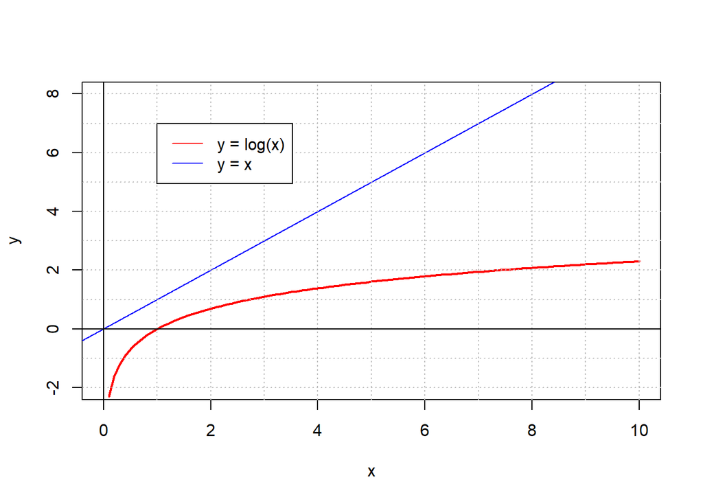

```r
# 対数関数 y = log(x) のグラフ
curve(log(x), # 対数関数
      ylab = "y", # y軸のラベル
      xlim = c(0, 10), # x軸の範囲
      ylim = c(-2, 8), # y軸の範囲
      col = "red", # 赤色
      lwd = 2) # 太線

# 直線 y = x を追加
abline(0, 1, # 切片, 傾き
       col = "blue") # 青色

# グリッドを追加
abline(h = -2:8, # 横線
       v = 0:10, # 縦線
       col = "gray", # 灰色
       lty = "dotted") # 点線

# x軸, y軸を追加
abline(h = 0, # x軸
       v = 0) # y軸

# 凡例を追加
legend(1, 7, # 左上の x, y 座標
       legend = c("y = log(x)", "y = x"), # 凡例
       col = c("red", "blue"), # 赤色, 青色
       lty = "solid") # 実線
```

よって, 対数変換には次の特徴がある.

- 値が大きいデータを縮小する
  - $\log (10) \approx 2.3$, $\log (1000) \approx 6.91$
  - ばらつきを縮小する
- 値が小さいデータを拡大する
  - $\log (0.01) \approx -4.61$, $\log (0.02) \approx -3.91$
  - ばらつきを拡大する

経済・ファイナンスデータに対しては, ばらつきを縮小するために対数変換を用いることが多い. データが負の場合は工夫が必要である. 例えば, $y_{t} > -1$ の場合は $\log(1 + y_{t})$ と変換すれば良い.

**変化率と対数差分**

変化率が小さいとき, 変化率と対数差分はほぼ等しい.

$$y_{t} = y_{t - 1} (1 + R_{t}) = y_{t - 1} e^{r_{t}}$$
より, 変化率と対数差分の関係は次である.
$$R_{t} = e^{r_{t}} - 1 \quad \text{or} \quad r_{t} = \log (1 + R_{t})$$

変化率が小さいとき $\log (1 + R_{t}) \approx R_{t}$ であるから, $r_{t} \approx R_{t}$.

$x = 0$ の近傍における $\log (1 + x)$ の Taylor 展開
$$\log (1 + x) = x - \frac{1}{2} x^{2} + \cdots$$
より, $x$ が $0$ に近いとき $\log (1 + x) \approx x$.

対数差分は理論的に扱いやすいので, 変化率よりも対数差分を用いる場合が多い.

- 値域
  - 変化率の値域は $[−1, \infty)$ であり, 正規分布の値域と異なる
  - 対数差分の値域は $(−\infty, \infty)$ であり, 正規分布の値域と同じ
- 平均
  - 変化率の平均 $\bar{R}$ と平均変化率 $R$ は異なる
    - 変化率の平均
      $$\bar{R} = \frac{1}{T} \sum_{t = 1}^{T} R_{t} = \frac{1}{T} \sum_{t =
      1}^{T} \frac{y_{t} - y_{t - 1}}{y_{t - 1}}$$
    - 平均変化率
      $$y_{T} = y_{T - 1} (1 + R_{T}) = \dots = y_{0} \prod_{t = 1}^{T} (1 +
      R_{t}) = y_{0} (1 + R)^{T}$$
      より
      $$(1 + R)^{T} = \prod_{t = 1}^{T} (1 + R_{t}) \quad \text{or} \quad R =
      \left[ \prod_{t = 1}^{T} (1 + R_{t}) \right]^{\frac{1}{T}} - 1$$
    - 一般的に, $\bar{R} \neq R$
  - 対数差分の平均 $\bar{r}$ と平均対数差分 $r$ は同じ
    - 対数差分の平均
      $$\bar{r} = \frac{1}{T} \sum_{t = 1}^{T} r_{t}$$
    - 平均対数差分
      $$y_{T} = y_{T - 1} e^{r_{T}} = \dots = y_{0} e^{r_{T} + \dots + r_{1}} =
      y_{0} e^{T r}$$
      より
      $$T r = \sum_{t = 1}^{T} r_{t} \quad \text{or} \quad r = \frac{1}{T}
      \sum_{t = 1}^{T} r_{t} = \bar{r}$$
    - よって, $\bar{r} = r$

独立に対数正規分布 (log-normal distribution, $\log y_{t} \sim N(\mu, \sigma^{2})$) に従う模擬データを用いて, 変化率と対数差分を求める.

```r
T <- 5 # 標本数
# 対数正規分布の模擬データを作成
(y <- rlnorm(T + 1, # 標本数
             5, 0.2)) # mu, sigma
```

```
## [1] 145.9644 111.4227 341.6839 178.9633 152.8234 144.6222
```

```r
(R <- diff(y) / head(y, -1)) # 変化率 = 差分 / 最後を削除
```

```
## [1] -0.23664437  2.06655479 -0.47623132 -0.14606274 -0.05366467
```

```r
(r <- diff(log(y))) # 対数差分
```

```
## [1] -0.2700313  1.1205547 -0.6467051 -0.1578976 -0.0551583
```

```r
mean(R) # 変化率の平均
```

```
## [1] 0.2307903
```

```r
prod(1 + R)^(1 / T) - 1 # 平均変化率
```

```
## [1] -0.001845805
```

```r
mean(r) # 対数差分の平均
```

```
## [1] -0.001847511
```

### 1.1.3 基本統計量と時系列モデル

**基本統計量**

一般的に, 基本的な統計量は次である.

- 平均 (mean), 分散 (variance), 標準偏差 (standard deviation)

時系列データでは, さらに次が重要となる.

- 時点 $t$ における $k$ 次 (ラグ $k$) の自己共分散 (autocovariance)
  $$\begin{align*}
  \gamma_{k, t} = \text{Cov} (y_{t}, y_{t - k}) = E [(y_{t} − \mu_{t})
  (y_{t - k} − \mu_{t - k})], \quad \mu_{t} = E [y_{t}]
  \end{align*}$$
- 時点 $t$ における $k$ 次 (ラグ $k$) の自己相関係数 (autocorrelation coefficient)
  $$\rho_{k, t} = \text{Cor} (y_{t}, y_{t - k}) = \frac{\gamma_{k,
  t}}{\sqrt{\gamma_{0, t}} \sqrt{\gamma_{0, t - k}}}$$

自己共分散, 自己相関係数をラグ $k$ の関数としてみたものを, 自己共分散関数 (autocovariance function), 自己相関関数 (autocorrelation function) という.

- コレログラム (correlogram): 自己相関関数のプロット

**時系列モデル**

時点 $t$ における $k$ 次の自己相関係数 $\rho_{k, t}$ を推定するためのデータは1つしかない. よって, データの性質や構造を仮定しなければ分析できない.

- 時系列データ $\{ y_{t} \}_{t = 1}^{T}$ を確率変数列 $\{ y_{t} \}_{t = -\infty}^{\infty}$ からの1つの実現値と考える
- 確率変数列の生成過程に関して, 性質や構造を仮定する  
  (推測統計において, 母集団を仮定することと同じ)

この確率変数列を確率過程 (stochastic process), データ生成過程 (DGP: data generating process) という.

- 時系列モデル: 確率過程の構造